# PA1_template

SGombar

December 24, 2016

## Introduction

This is SGombars solution to the week 2 project in the reporducible research course of the data science specialization.

## Basic Data Descriptions

1. Load essential libraries

```r
library(ggplot2)
```

2. Load the activity.csv file assumed in the current working directory

```r
dat <- read.csv("./activity.csv", header=TRUE, stringsAsFactors = TRUE)
```

3. Create a histogram of the total steps per day

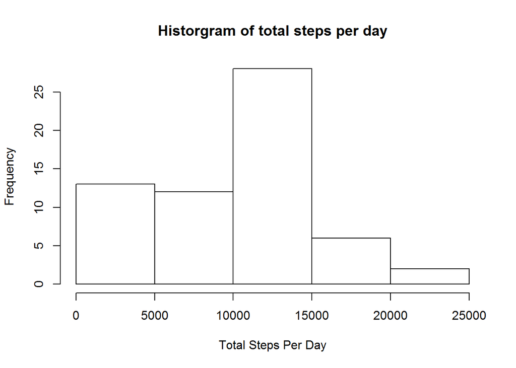

```r
allDaySums <- c()
for (day in unique(dat$date)){
  daySum <- sum(dat[dat$date == day,1], na.rm = TRUE)
  allDaySums <- c(allDaySums, daySum)

}
hist(allDaySums, main = "Historgram of total steps per day", xlab = "Total Steps Per Day")
```

4. Mean per day: 9354.2295082 and Median per day : 10395
5. Create a time series plot of average steps per time slot

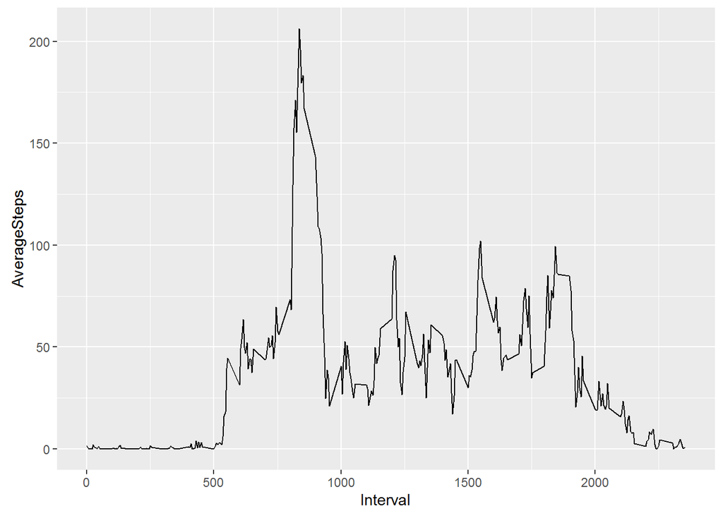

```r
allTimes <- c()
for (timeSlot in unique(dat$interval)){
  timeAverage <- mean(dat[dat$interval == timeSlot,1], na.rm = TRUE)
  allTimes <- c(allTimes, timeAverage)
}
timeDF <- as.data.frame(cbind(unique(dat$interval), allTimes))
colnames(timeDF) <- c("Interval","AverageSteps")
ggplot(timeDF, aes(x=Interval, y=AverageSteps)) + geom_line()
```

```r
maxStepIntervalTime = timeDF[which.max(timeDF$AverageSteps),1]
```

6. The interval with the maxium average steps is 835.

## Dealing with missing data

1. How much missing data?

```r
MissingValues <- sum(is.na(dat))
```

1. There is 2304 NA values within steps.
2. Imputing Data Strategy: Fill any NA values with the mean for the same interval (mean disregarding NAs).

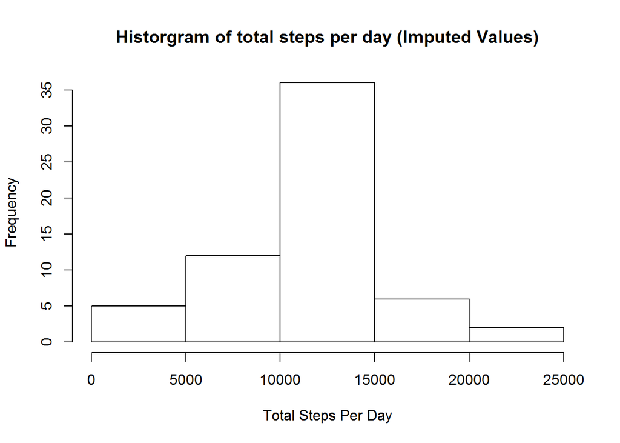

```r
impDat <- dat
for(i in 1:nrow(dat)){
  if(is.na(dat[i,1])){
    impDat[i,1] <- timeDF[timeDF$Interval==impDat[i,3],2]
  }
}

allImpDaySums <- c()
for (day in unique(impDat$date)){
  daySum <- sum(impDat[impDat$date == day,1], na.rm = TRUE)
  allImpDaySums <- c(allImpDaySums, daySum)

}
hist(allImpDaySums, main = "Historgram of total steps per day (Imputed Values)", xlab = "Total Steps Per Day")
```

## The effect of weekdays

1. Add a field to all the imputed data points denoting weekend or weekday.

```r
isWeekend <- vector(mode="character", length=nrow(impDat))
for(i in 1:nrow(impDat)){
  if(weekdays(as.Date(impDat[i,2])) %in% c("Saturday","Sunday")){
    isWeekend[i] <- "Weekend"
  } else {
    isWeekend[i] <- "Weekday"
  }
}

impDat$isWeekend <- as.factor(isWeekend)
```

2. Now using the weekend information create a new time series for weekend and weekday and plot them.

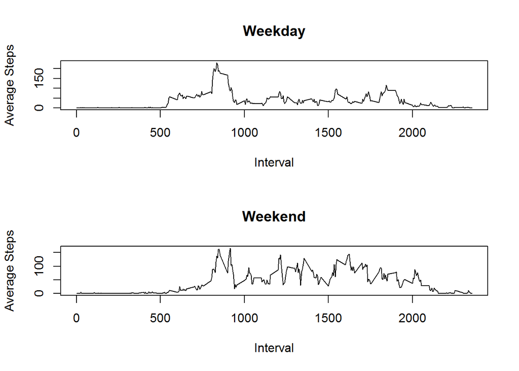

```r
weekdayDat <- impDat[impDat$isWeekend=="Weekday",]
allWeekdayTimes <- c()
for (timeSlot in unique(weekdayDat$interval)){
  timeAverage <- mean(weekdayDat[weekdayDat$interval == timeSlot,1], na.rm = TRUE)
  allWeekdayTimes <- c(allWeekdayTimes, timeAverage)
}
timeDF <- as.data.frame(cbind(unique(weekdayDat$interval), allWeekdayTimes))


weekendDat <- impDat[impDat$isWeekend=="Weekend",]
allWeekendTimes <- c()
for (timeSlot in unique(weekendDat$interval)){
  timeAverage <- mean(weekendDat[weekendDat$interval == timeSlot,1], na.rm = TRUE)
  allWeekendTimes <- c(allWeekendTimes, timeAverage)
}
timeDF <- cbind(timeDF, allWeekendTimes)
colnames(timeDF) <- c("Interval","Weekday","Weekend")

par(mfrow=c(2,1))
plot(timeDF$Interval, timeDF$Weekday, type = 'l', ylab = "Average Steps", xlab = "Interval", main = "Weekday")
plot(timeDF$Interval, timeDF$Weekend, type = 'l', ylab = "Average Steps", xlab = "Interval", main = "Weekend")
```